# Feasibility of Extended‐interval Follow‐up for Patients Receiving Warfarin - Carris - 2015 - Cardiovascular Therapeutics - Wiley Online Library

[Cardiovascular Therapeutics](https://onlinelibrary.wiley.com/journal/17555922)

[Volume 33, Issue 3](https://onlinelibrary.wiley.com/toc/17555922/2015/33/3) p. 98-103

[figure not shown]

Original Research Article

Free Access

# Feasibility of Extended-interval Follow-up for Patients Receiving Warfarin

[Nicholas W. Carris](https://onlinelibrary.wiley.com/action/doSearch?ContribAuthorRaw=Carris%2C+Nicholas+W),

[Alisa Spinelli](https://onlinelibrary.wiley.com/action/doSearch?ContribAuthorRaw=Spinelli%2C+Alisa),

[Danielle Pierini](https://onlinelibrary.wiley.com/action/doSearch?ContribAuthorRaw=Pierini%2C+Danielle),

[James R. Taylor](https://onlinelibrary.wiley.com/action/doSearch?ContribAuthorRaw=Taylor%2C+James+R),

[Katherine Vogel Anderson](https://onlinelibrary.wiley.com/action/doSearch?ContribAuthorRaw=Anderson%2C+Katherine+Vogel),

[Karen Sando](https://onlinelibrary.wiley.com/action/doSearch?ContribAuthorRaw=Sando%2C+Karen),

[Jason Powell](https://onlinelibrary.wiley.com/action/doSearch?ContribAuthorRaw=Powell%2C+Jason),

[Eric I. Rosenberg](https://onlinelibrary.wiley.com/action/doSearch?ContribAuthorRaw=Rosenberg%2C+Eric+I),

[Marc S. Zumberg](https://onlinelibrary.wiley.com/action/doSearch?ContribAuthorRaw=Zumberg%2C+Marc+S),

[Steven M. Smith](https://onlinelibrary.wiley.com/action/doSearch?ContribAuthorRaw=Smith%2C+Steven+M),

… See all authors

First published: 18 March 2015

https://doi.org/10.1111/1755-5922.12115

Citations: 9

Check for Full Text

## Summary

### Aims

The 2012 American College of Chest Physician Evidence-Based Management of Anticoagulant Therapy guidelines suggest an international normalized ratio (INR) testing interval of up to 12 weeks, rather than every 4 weeks, for patients with consistently stable INRs while taking vitamin K antagonists. We aimed to examine the feasibility of extended-interval follow-up in a real-world setting.

### Results

Of 48 patients enrolled, 47 had evaluable data. The most common indication for anticoagulation was atrial fibrillation/flutter (53.2%). At baseline, mean prior warfarin treatment duration was 6.7 ± 6 years and median number of weeks on a stable regimen was 24 weeks (IQR, 19–37.5). Eleven patients (23%) completed all study follow-up visits, whereas 17 (36%) did not maintain a stable INR past the 14-week follow-up.

### Conclusion

A large proportion of patients with previously stable (≥3 months) INRs were not able to maintain stable INRs during extended-interval follow-up. More research is needed to identify patient characteristics predictive of success with extended-interval follow-up prior to broad implementation.

## Introduction

Warfarin is standard care for many conditions requiring anticoagulation, but its use is limited by numerous interactions and the need for frequent monitoring 1. Because of the wide range of factors that can affect the international normalized ratio (INR) during warfarin therapy, providers are generally expected to use clinical discretion in determining the most appropriate frequency of INR monitoring for a given patient. However, the most appropriate maximum frequency for INR monitoring in patients taking warfarin—particularly those with generally stable INRs—is not known. Ninety-day follow-up is common in the United Kingdom while by convention in the United States 4-week follow-up is generally considered the maximum interval 1.

The 2012 American College of Chest Physician Evidence-Based Management of Anticoagulant Therapy (CHEST) guidelines produced several new recommendations regarding vitamin K antagonist (VKA) management including an option to extend the interval of outpatient INR monitoring up to 12 weeks for patients with stable INRs, defined as an INR consistently at goal for ≥3 months and no requirement for VKA dose adjustment 1. This new recommendation was based on three studies supporting extended-interval follow-up (>4-week intervals) 2-4. However, only one of these studies examined follow-up intervals as long as 12 weeks 4. This study compared 4-week versus 12-week INR monitoring and warfarin dose assessment and found no difference between groups in the rate of thromboembolism, bleeding, or INR stability 4. Nearly 92% of patients in the 12-week monitoring arm completed the study, suggesting that this strategy can be used safely. However, patients who were randomly assigned to 12-week follow-up still had contact with a study investigator at 4-week intervals. Thus, whether 12-week interval monitoring is feasible in real-world patients is unknown. Accordingly, we implemented extended-interval follow-up per 2012 CHEST guideline recommendations to determine the feasibility of extended-interval follow-up in a real-world setting and to identify patient characteristics predictive of successful extended-interval follow-up.

## Methods

### Study Population and Design

This prospective single-arm intervention pilot study recruited established patients from five University of Florida Ambulatory Care Research Network (UF-ACRN) outpatient anticoagulation clinics in Gainesville, FL. Prior to enrollment typical follow-up interval for stable patients was 4 weeks. The general interval escalation after a warfarin dose change in our clinics is 1 week, 2 weeks, 4 weeks, assuming continued stability and no other mitigating factors. Based on the inclusion criteria, all patients would have been eligible for traditional 4-week follow-up at the time of enrollment. However, due to patient preference (e.g., work schedule, vacations) or clinician preference (e.g., closer follow-up for patient-specific factors without warfarin dose change) not all patients were followed up at the same interval immediately prior to starting study procedures.

We included males and females aged 18–90 years if they required at least 6 months of anticoagulation, had been followed by the same anticoagulation clinic for at least 12 weeks prior to enrollment, and had consistent INRs for the previous 12 weeks as evidenced by not requiring a warfarin dose change. Exclusion criteria were life expectancy <24 months, inability to provide informed consent, thromboembolic event in previous 12 weeks, pregnancy, cancer diagnosis in prior year, or actively receiving cancer treatment. Concordant with the CHEST guidelines, elevated bleeding risk was not explicitly considered in determining appropriateness for extended-interval follow-up.

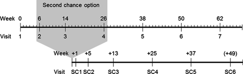

**Figure 1**

Open in figure viewer[PowerPoint](https://onlinelibrary.wiley.com/action/downloadFigures?id=cdr12115-fig-0001&doi=10.1111%2F1755-5922.12115)

Study timeline. The (+) sign indicates number of weeks from the initial follow-up upon entering second-change procedures; numbers in parentheses represent possible visits depending on when second-change procedures were initiated. SC, second-chance.

A pharmacist and physician at each site were responsible for implementing the protocol and making clinical decisions regarding continuation in the study based on the criteria outlined. The study was approved by the University of Florida Institutional Review Board, and all patients provided written informed consent.

### Study Outcomes

The primary outcome was percent of patients completing all study follow-up visits including those who did and did not require second-chance. This outcome was chosen as a measure of feasibility of implementation of extended-interval follow-up per 2012 CHEST guidelines. Secondary outcomes were percentage of patients completing all study follow-up visits without requiring second-chance, percentage of patients who entered second-chance who went on to complete all remaining study visits, median weeks of extended-interval follow-up from baseline, reasons for removal from extended-interval follow-up, factors precipitating out-of-range INR values, baseline factors associated with weeks of extended-interval follow-up, and bleeding and thromboembolic events.

### Statistical Analysis

Descriptive statistics were used to characterize the study population. Because follow-up time data were positively skewed, the Wilcoxon rank-sum test was used for bivariate analyses, and Spearman correlation coefficients were calculated for comparison of extended-interval follow-up duration with other continuous variables. A *P*-value < 0.05 was considered statistically significant. We analyzed data using SAS version 9.3 (SAS Institute, Cary, NC, USA). Study data were collected and managed using REDCap, a secure, web-based application designed to support data capture for research studies 6.

## Results

A total of 48 patients were enrolled from five study sites between September 2012 and December 2012. One patient did not meet eligibility criteria and was withdrawn from the study and excluded from further analysis. Thus, the final evaluable dataset included 47 patients. Demographic and clinical characteristics of these patients are summarized in Table 1. The mean age was 67 years and the vast majority of patients self-reported race as White (75%) or Black (21%). The most common indication for chronic warfarin use was nonvalvular atrial fibrillation or flutter, followed by prevention of recurrent deep venous thromboembolism (DVT) or pulmonary embolism (PE). By chance, all enrolled patients had an INR goal of 2–3. Prior to enrollment, the median number of weeks on a stable warfarin regimen was 24 weeks (IQR, 19–37.5). Additionally, 44 patients (94%) had been taking warfarin for >1 year. Two patients (4%) reported being hospitalized for bleeding in the past year.

Table 1. Baseline characteristics of participants with evaluable data (n = 47)

| Characteristic | Mean ± SD or n (%) |
| --- | --- |
| Age, years | 66.8 ± 12.5 |
| Male | 22 (46.8) |
| Number of medications taken daily | 6.9 ± 4.6 |
| Race/ethnicity |  |
| White (non-Hispanic) | 35 (74.5) |
| Black (non-Hispanic) | 10 (21.3) |
| Other | 2 (4.3) |
| Indication for chronic warfarin |  |
| Nonvalvular atrial fibrillation or flutter | 25 (53.2) |
| Prevention of recurrent DVT or PE | 14 (29.8) |
| Other | 2 (4.3) |
| Multiple indications | 6 (12.8) |
| Anticoagulation-related factors |  |
| Weeks with consistent INR | 33.0 ± 27.76 |
| Total weekly dose (mg) | 38.1 ± 17.40 |
| Duration of chronic warfarin use, years | 6.74 ± 6.01 |
| Any hospitalization in past year for bleeding event | 2 (4.3) |
| Using pill box | 30 (63.8) |
| Patient reported planned servings of vitamin K containing foods per week | 3.95 ± 3.88 |

- DVT, deep venous thromboembolism; INR, international normalized ratio; PE, pulmonary embolism.

Eleven patients (23%) completed all study follow-up visits. Of these, 9 (82%) completed all study follow-up visits without requiring second-chance procedures. In total, 11 of the 47 patients (23%) were transitioned to second-chance, and of these, 2 (18%) subsequently completed all study follow-up visits after entering second-chance procedures. Patients completed a median of 5 study visits (range, 1–7) and 36 weeks (range, 1–64) of extended-interval follow-up: 13 patients (28%) completed at least 1 year of extended-interval follow-up, 21 patients (45%) completed at least 39 weeks of extended-interval follow-up (Figure 2). Seventeen patients (36%) were removed at week 14 or earlier, prior to qualifying for 12-week follow-up. Eleven of these 17 patients (65%) had been stable on their current warfarin dose for at least 20 weeks prior to their enrollment in the study. Figure 3 shows the reasons for study discontinuation.

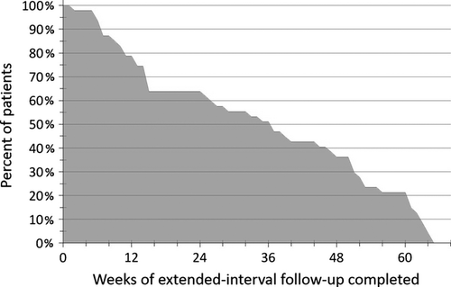

**Figure 2**

Open in figure viewer[PowerPoint](https://onlinelibrary.wiley.com/action/downloadFigures?id=cdr12115-fig-0002&doi=10.1111%2F1755-5922.12115)

Percent of patients continuing in the study according to achieved number of weeks of extended-interval follow-up.

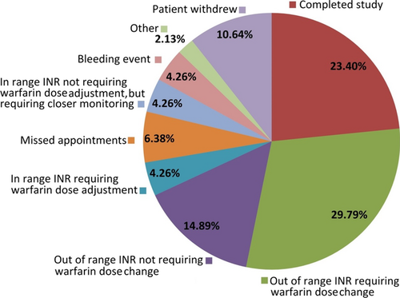

**Figure 3**

Open in figure viewer[PowerPoint](https://onlinelibrary.wiley.com/action/downloadFigures?id=cdr12115-fig-0003&doi=10.1111%2F1755-5922.12115)

Reasons for study termination (n = 47).

Sixteen patients (34%) were removed from the study due to requiring a warfarin dose change, 7 (15%) for an INR excursion that warranted closer follow-up without a dose change, and 2 (4%) for requiring closer monitoring despite an in-range INR. Of the 2 patients who were removed from the study for requiring closer monitoring despite an in-range INR, one began second-chance procedures and returned to clinic at next follow-up with a therapeutic INR; however, the patient's INR was not likely enough to remain therapeutic to continue extended-interval follow-up. Therefore, the patient was removed from the study. The second patient was removed from the study required an interruption of warfarin therapy for a procedure late in the study and therefore did not qualify for second-chance.

No baseline factors were significantly associated with achieved number of weeks of extended-interval follow-up (Table 2). However, taking the same dose each day of the week was marginally associated (*P* = 0.089) with achieving a greater number of weeks of extended-interval follow-up. In unadjusted correlation analyses, the number of weeks of completed extended-interval follow-up was marginally associated with age (*ρ* = 0.28; *P* = 0.060), number of medications currently used (*ρ* = −0.27; *P* = 0.076), and previous number of weeks stable on current warfarin dose (*ρ* = 0.27; *P* = 0.062). Number of years of treatment with warfarin was not associated with the number of weeks of extended-interval follow-up completed (*ρ* = −0.05; *P* = 0.74).

Table 2. Weeks of extended-interval follow-up according to selected baseline variables

[output not shown]

Easy bruising was the most commonly reported adverse event, which was reported six times total, by three separate patients. No thromboembolic events occurred. Two patients (4%) were removed from the study due to bleeding events (nose bleed and rectal bleed). Both events resolved and occurred while the INR was <3. Neither was determined to be related to study procedures. Five patients withdrew from the study. One patient specifically requested more frequent monitoring. Serious adverse events occurred in five patients. However, none were associated with bleeding or thrombosis, and none were determined to be associated with extended-interval follow-up. One patient presented to the emergency department with stress-induced syncope. One patient was admitted for evaluation of presyncope. One patient was admitted for possible acute coronary syndrome, which was ruled out. One patient presented to emergency department with hematoma on left lower leg (INR 2.3 on ED admission). The final patient was admitted for treatment of pneumonia, with an INR on admission of >8, which was determined to be secondary to concurrent pneumonia. The patient was discharged on home warfarin dose (INR 2.1 on discharge) and subsequently removed from the study for requiring more frequent monitoring.

## Discussion

To our knowledge, this study is the first to examine the real-world feasibility of extended-interval follow-up of patients on warfarin according to recent CHEST guideline recommendations. The CHEST guideline criterion for initiating extended-interval follow-up did not portend successful long-term use of extended-interval follow-up in a large majority of patients included in this study. Surprisingly, greater than one-third of patients were removed from the study prior to qualifying for 12-week follow-up despite meeting inclusion criteria based on CHEST guideline recommendations, including a previously stable (≥12 weeks) INR and warfarin dose. Interestingly, patients entering second-chance procedures early in the study to continue extended-interval follow-up were no more likely to complete all study follow-up visits compared to the overall cohort or patients who only received a first chance.

The randomized controlled trial by Schulman and colleagues concluded that warfarin dosing assessment at 12-week intervals seems to be noninferior compared with 4-week interval assessments 4. Because they did not disqualify patients for INR excursion and dose changes, time in therapeutic range (TTR) was an appropriate quality measure for anticoagulation therapy. However, because we disqualified patients from extended-interval follow-up for multiple reasons (e.g., repeat INR excursion, warfarin dose change), this would significantly and falsely elevate TTR for our study. Therefore, we chose the percent of patients successfully completing follow-up in this fashion for approximately a year as a more appropriate measure of feasibility of extended-interval follow-up. Interestingly, in their study, greater than one-third of the patients followed every 12 weeks required at least one dose change, and nearly one in four required at least two dose changes. This proportion is similar to the percentage of patients removed from our study for requiring a dose change.

Our study has notable limitations. First, our small sample size may limit generalizability and cause imprecision in our results. Second, our results may have differed if patient follow-up occurred over a longer time period. In practice, “second-chance” procedures described herein could be available at any time in follow-up. We could not ascertain whether patients who completed >26 weeks of extended-interval follow-up would have achieved long-term stability with extended-interval follow-up if given additional opportunities.

## Conclusion

This study highlights that successful implementation of extended-interval follow-up may not be feasible for a broad range of patients despite apparent INR stability. The major potential advantages to less frequent follow-up are reduced cost and improved patient satisfaction. However, empirical data on these outcomes are scant. Thus, whether extended-interval follow-up in the real-world setting results in cost savings or improved patient satisfaction is unknown. In light of these limitations and our findings, we offer three points of guidance regarding extended-interval follow-up. First, reassess patient suitability for extended-interval follow-up at each visit. Second, establish predefined minimum criteria for continuing extended-interval follow-up. Third, employ shared decision-making between the patient and provider when selecting a follow-up interval.

## Acknowledgments

The authors would like to thank Jennifer Elliott, PharmD for effort in designing and initiating this study and Patrick Cogan, PharmD for efforts coordinating a clinic site during the study.

## Conflict of Interest

Dr. M.S.Z reports being the medical director for NCF diagnostics and DNA technology.

## Citing Literature

[figure not shown]

[Volume33, Issue3](https://onlinelibrary.wiley.com/toc/17555922/2015/33/3)

June 2015

Pages 98-103

### Recommended

  [British Journal of Haematology](https://onlinelibrary.wiley.com/journal/13652141)

[Download PDF](https://onlinelibrary.wiley.com/doi/pdf/10.1111/1755-5922.12115)

back

Close

[figure not shown]